# Analysis of Time Series-An Introduction

Author

Rick Dean

Abstract

The following notes/scripts/plots are inspired by the book [The Analysis of Time Series: An Introduction](http://www.ams.sunysb.edu/~xing/tsRbook/index.html) by Chris Chatfield and Haipeng Xing

```r
library(data.table)
library(ggplot2)
library(grid)
library(gtable)
library(RplotterPkg)
library(RtsaPkg)
```

# 3 Some Linear Time Series Models

## 3.4 Purely Random Processes

Compute and display a purely random series and its autocorrelation.

Create 500 points of a random series with 0 mean and variance of 1.

```r
random_df <- data.frame(
  Time = seq(1,500,1),
  Series = rnorm(n = 500, mean = 0, sd = 1)
)
```

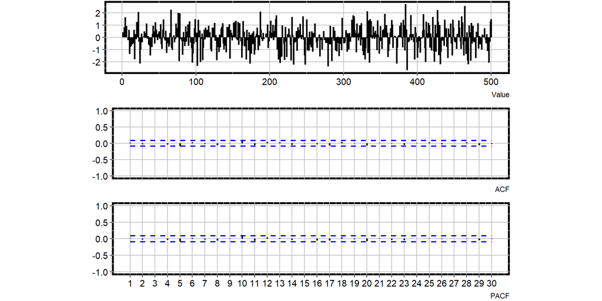

Autocorrelation from a Random Normal Distribution

```r
RtsaPkg::graph_acf(
  df = random_df,
  time_col = "Time",
  value_col = "Series",
  confid_level = 1.96
)
```

## 3.5 Random Walks

Suppose that $Z_t$ is a purely random process with mean $\mu$ and variance $\sigma_Z^2$. A process $X_t$ is said to be a random walk if
$$X_t = X_{t-1} + Z_t$$
The process starts at zero when $t = 0$ so that
$$X_1 = Z_1$$
and
$$X_t = \sum_{i=1}^tZ_i$$
$X_t$ is the sum of a random process and we find that $E(X_t) = t\mu$ and $Var(X_t) = t\sigma_z^2$ since the $Z_i$’s are independent. As the mean and variance change with $t$, the process is non-stationary.

It is interesting to note that the first differences of a random walk, given by:
$$\Delta X_t = X_t - X_{t-1} = Z_t$$
forms a purely random process, which is therefore stationary. The best-known examples of time series which behave like random walks are share prices on successive days. A model which often gives a good approximation to such data is:

*share price on day* $t$ = *share price on day* $(t-1)$ + random error

Create and plot a random walk process.

```r
random_walk_df <- data.frame(
  Time = seq(1,500,1),
  Series = cumsum(rnorm(n = 500, mean = 0, sd = 1))
)
```

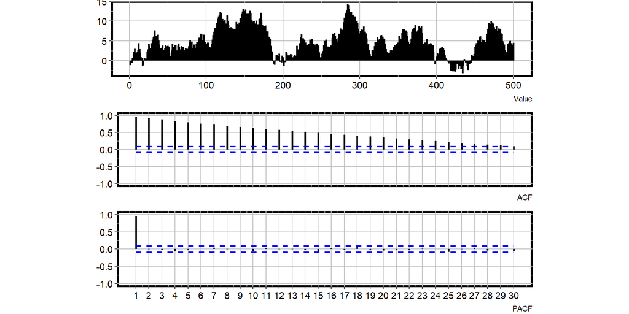

Autocorrelation from a Random Walk Normal Distribution

```r
acf_random_walk <- RtsaPkg::graph_acf(
  df = random_walk_df,
  time_col = "Time",
  value_col = "Series",
  confid_level = 1.96
)
```

The random walk appears to be non-stationary with the mean and variance changing with $t$ and that there is a significant correlation at lag 1.

Take first differences of the above random walk and plot the ACF to check if the significant lag 1 still holds up.

```r
random_walk_diff <- RtsaPkg::graph_dif(
  df = random_walk_df,
  time_col = "Time",
  value_col = "Series",
  show_pts = FALSE,
  show_obs = FALSE,
  display_plot = FALSE
)
```

Plot the ACF/PACF of the random walk’s first order differences:

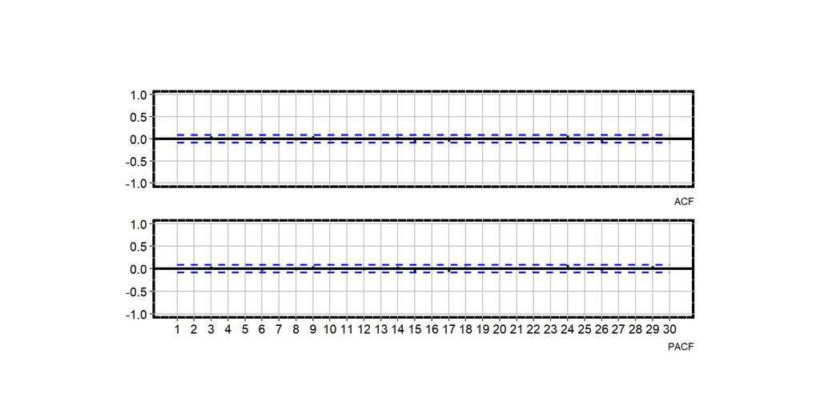

ACF & PACF of Random Walk First Differences

```r
graph_acf(
  df = random_walk_diff$diff_df,
  time_col = "datetime",
  value_col = "diffvalue",
  title = "",
  confid_level = 1.96,
  show_obs = FALSE,
  bold_y = 0.0
)
```

Appears that we are back to a stationary random process without any significant lags.

## 3.6 Moving Average Processes

### 3.6.1 Stationarity and autocorrelation function of an MA process